# General crop model performance figures

### Latitudinal scatterplot

Then we also want to create a scatterplot showing the model ensemble performance (Rsquared) along the latitudinal axis (y). We use the geom_smooth(method = “gam”) to fit a smooth nonlinear trendline.

```r
# Generate latitudinal distribution plot
lat_plot <- ggplot(ens_map_aggr, aes(x = lat, y = rsquared)) +
  geom_point(alpha = 0.3, color = "#3288bd") +
  geom_smooth(method = "gam", color = "black", fill = "gray80") +
  labs(x = "Latitude", y = expression(R^2)) +
  theme(axis.title.x = element_text(size = 25), axis.title.y = element_text(size = 12)) +
  coord_flip() +
  scale_x_continuous(limits = c(-45, 60), breaks = c(-40, -20, 0, 20, 40))
  ylim(0, 1)
```

```
<ScaleContinuousPosition>
 Range:
 Limits:    0 --    1
```

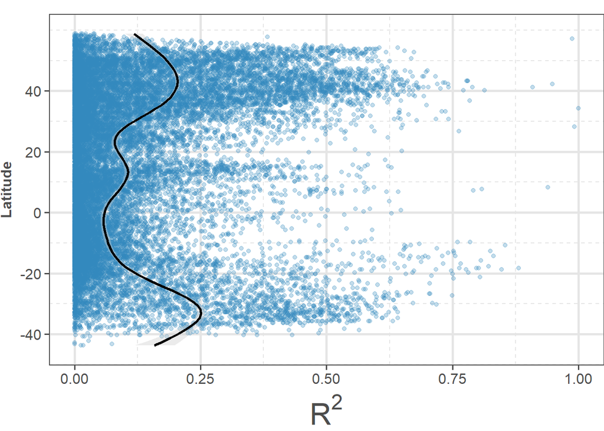

```r
lat_plot
```

```r
# Save the latitudinal plot
#ggsave(file.path(base_path, "GGCMI-validation/results/main/fig1b_LatitudinalScatter.png"),
    # lat_plot, width = 12, height = 12, dpi = 300)
```

We first define a function to calculate RMSE and KGE. Note that for KGE we use a self-customized version (KGE’). The original KGE can be calculated as KGE = 1-KGE’.

```r
# Define RMSE function
rmse <- function(observed, predicted) {
  sqrt(mean((observed - predicted) ^ 2))
}

# Function to calculate KGE components
calculate_kge<- function(benchmark, simulated) {
  r <- cor(benchmark, simulated, use = "complete.obs")  # Correlation
  Beta <- (mean(simulated, na.rm = TRUE) - mean(benchmark, na.rm = TRUE)) / sd(benchmark, na.rm = TRUE)  # Bias (Beta)
  Alpha <- sd(simulated, na.rm = TRUE) / sd(benchmark, na.rm = TRUE)  # Variability (Alpha)

  kge <- sqrt((r - 1)^2 + (Alpha - 1)^2 + (Beta)^2)  # Calculate KGE

  return(list(KGE = kge, r = r, Beta = Beta, Alpha = Alpha))  # Return all components
}
```

Then, we can calculate the metrics per model. To calculate the global performance, we average the metric values across all grid cells and years. We do this by taking a mean, weighted for the harvest area of the respective grid cell (HAWM). This means that grid cells where a lot of crops are produced, weight more in the calculation of the mean and thus have a higher influence than low-producing locations.

```r
performance_metrics <- crop_data[["aggr"]] %>%
  inner_join(general_sim_aggr %>% dplyr::select(lat, lon, year, difftrend_sim, model), by = c("lat", "lon", "year")) %>%
   distinct() %>%
  drop_na(difftrend_obs, difftrend_sim) %>% # Remove rows with NAs in either column
  group_by(model, lat, lon) %>%
  filter(sd(difftrend_obs) > 0, sd(difftrend_sim) > 0) %>%
  summarise(RMSE = rmse(difftrend_obs, difftrend_sim),
            Rsquared = cor(difftrend_obs, difftrend_sim)^ 2,
            KGE_components = calculate_kge(difftrend_obs, difftrend_sim),
            sd = sd(difftrend_sim),
           total_area = first(total_area)) %>%
  mutate(
    KGE = KGE_components$KGE,
    r = KGE_components$r,
    Beta = KGE_components$Beta,
    Alpha = KGE_components$Alpha
  ) %>% dplyr::select(-KGE_components)  %>%
  group_by(model) %>%
  summarise(HAWM_RMSE = sum(RMSE*total_area)/sum(total_area),
            HAWM_Rsquared = sum(Rsquared*total_area)/sum(total_area),
            HAWM_KGE = sum(KGE*total_area)/sum(total_area),
            HAWM_Alpha = sum(Alpha*total_area)/sum(total_area),
            HAWM_beta = sum(Beta*total_area)/sum(total_area),
            HAWM_sd = sum(total_area * sd)/sum(total_area)) %>%
  distinct()
```

Then we can plot these values in a heatmap table. Note that we have to normalize the values to create a common color scheme for lower to higher performance.

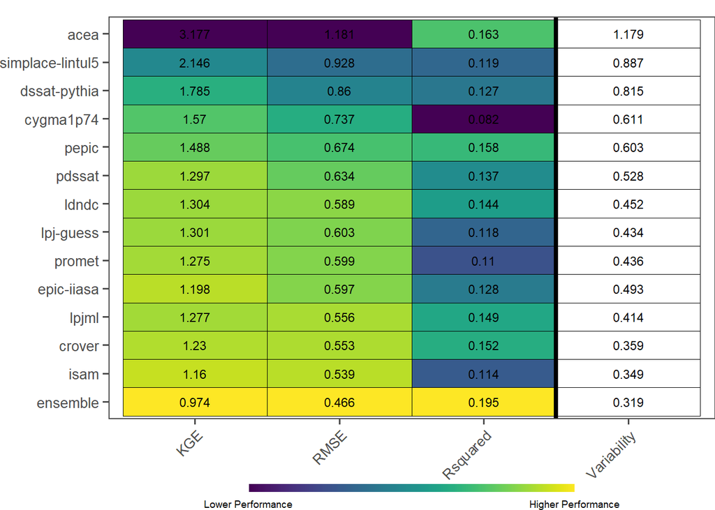

```r
# Reshape and rename metric names for the table plot
performance_metrics_long <- performance_metrics %>%
  dplyr::select(model, HAWM_KGE, HAWM_sd, HAWM_RMSE, HAWM_Rsquared) %>%
  pivot_longer(cols = -model, names_to = "Metric", values_to = "Value") %>%
  mutate(Metric = recode(Metric,
                         "HAWM_KGE" = "KGE",
                         "HAWM_sd" = "Variability",
                         "HAWM_RMSE" = "RMSE",
                         "HAWM_Rsquared" = "Rsquared")) %>%
  group_by(Metric) %>%
  mutate(
    # Normalize value within each metric, reversing Rsquared for higher=better
    Normalized_Value = ifelse(
      Metric == "Rsquared",
      (Value - min(Value)) / (max(Value) - min(Value)),  # Rsquared higher is better
      (max(Value) - Value) / (max(Value) - min(Value))   # Others lower is better
    )
  ) %>%
  ungroup()

# Filter out 'Variability' for coloring purposes but keep for ordering
performance_metrics_long$fill_color <- ifelse(performance_metrics_long$Metric == "Variability", NA, performance_metrics_long$Normalized_Value)

# Create the table plot
table_plot <- ggplot(performance_metrics_long, aes(x = Metric, y = reorder(model, Value), fill = fill_color)) +
  geom_tile(color = "black") +  # Outline tiles
  geom_text(aes(label = round(Value, 3)), color = "black", size = 3) +  # Add text labels
  geom_vline(xintercept = 3.5, color = "black", size = 1.5) +  # Thicker line at x=2.5 (between columns 2 and 3)
  scale_fill_viridis(
    discrete = FALSE,
    option = "viridis",
     na.value = "white" , # Color for 'Variability' set to white
    name = "",  # Remove the legend title
    breaks = c(0, 1),
    labels = c("Lower Performance", "Higher Performance")
  )  +
  theme(
    axis.text.x = element_text(angle = 45, hjust = 1, size = 10),
    axis.text.y = element_text(size = 10),
    axis.title.x = element_blank(),
  axis.title.y = element_blank(),
    panel.grid = element_blank(),
    legend.position = "bottom",
    legend.title = element_text(size = 10),
    legend.text = element_text(size = 7),
    legend.margin = margin(t = -10, unit = "pt"),  # Adjust top margin to move color bar closer
  legend.spacing.y = unit(0.1, "pt")            # Reduce spacing between legend and plot
  ) +
    labs(x = "", y = "", fill = "") +  # Add a label to the color bar
  guides(
    fill = guide_colorbar(
      title = NULL,
      barwidth = 16,
      barheight = 0.4,
    )
  )

table_plot
```

```r
# Save the table plot
#ggsave(file.path(base_path, "GGCMI-validation/results/main/fig1c_PerformanceTableHAWM.png"),
     #table_plot, width = 6, height = 4, dpi = 300)
```

## Supplementary figure 1

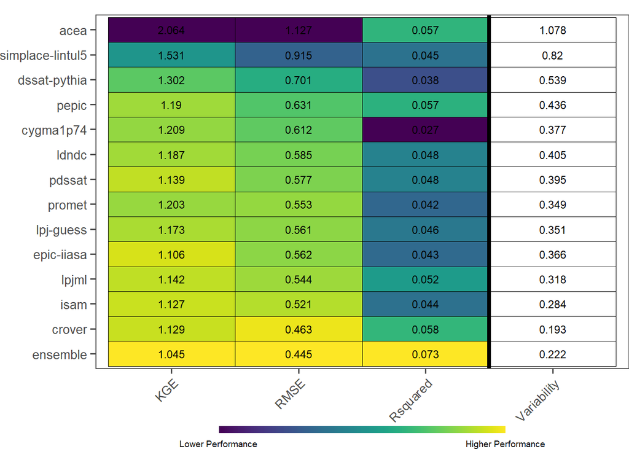

```r
performance_metrics <- crop_data[["aggr"]] %>%
  inner_join(general_sim_aggr %>% dplyr::select(lat, lon, year, difftrend_sim, model), by = c("lat", "lon", "year")) %>%
   distinct() %>%
  drop_na(difftrend_obs, difftrend_sim) %>% # Remove rows with NAs in either column
  group_by(model, lat, lon) %>%
  filter(sd(difftrend_obs) > 0, sd(difftrend_sim) > 0) %>%
  summarise(RMSE = rmse(difftrend_obs, difftrend_sim),
            Rsquared = cor(difftrend_obs, difftrend_sim)^ 2,
            KGE_components = calculate_kge(difftrend_obs, difftrend_sim),
            sd = sd(difftrend_sim),
           total_area = first(total_area)) %>%
  mutate(
    KGE = KGE_components$KGE,
    r = KGE_components$r,
    Beta = KGE_components$Beta,
    Alpha = KGE_components$Alpha
  ) %>% dplyr::select(-KGE_components)  %>%
  group_by(model) %>%
  summarise(mean_RMSE = median(RMSE),
            mean_Rsquared = median(Rsquared),
            mean_KGE = median(KGE),
            mean_Alpha = median(Alpha),
            mean_beta = median(Beta),
            mean_sd = median(sd)) %>%
  distinct()

# Reshape and rename metric names for the table plot
performance_metrics_long <- performance_metrics %>%
  dplyr::select(model, mean_KGE, mean_sd, mean_RMSE, mean_Rsquared) %>%
  pivot_longer(cols = -model, names_to = "Metric", values_to = "Value") %>%
  mutate(Metric = recode(Metric,
                         "mean_KGE" = "KGE",
                         "mean_sd" = "Variability",
                         "mean_RMSE" = "RMSE",
                         "mean_Rsquared" = "Rsquared")) %>%
  group_by(Metric) %>%
  mutate(
    # Normalize value within each metric, reversing Rsquared for higher=better
    Normalized_Value = ifelse(
      Metric == "Rsquared",
      (Value - min(Value)) / (max(Value) - min(Value)),  # Rsquared higher is better
      (max(Value) - Value) / (max(Value) - min(Value))   # Others lower is better
    )
  ) %>%
  ungroup()

# Filter out 'Variability' for coloring purposes but keep for ordering
performance_metrics_long$fill_color <- ifelse(performance_metrics_long$Metric == "Variability", NA, performance_metrics_long$Normalized_Value)

# Create the table plot
table_plot <- ggplot(performance_metrics_long, aes(x = Metric, y = reorder(model, Value), fill = fill_color)) +
  geom_tile(color = "black") +  # Outline tiles
  geom_text(aes(label = round(Value, 3)), color = "black", size = 3) +  # Add text labels
  geom_vline(xintercept = 3.5, color = "black", size = 1.5) +  # Thicker line at x=2.5 (between columns 2 and 3)
  scale_fill_viridis(
    discrete = FALSE,
    option = "viridis",
     na.value = "white" , # Color for 'Variability' set to white
    name = "",  # Remove the legend title
    breaks = c(0, 1),
    labels = c("Lower Performance", "Higher Performance")
  )  +
  theme(
    axis.text.x = element_text(angle = 45, hjust = 1, size = 10),
    axis.text.y = element_text(size = 10),
    axis.title.x = element_blank(),
  axis.title.y = element_blank(),
    panel.grid = element_blank(),
    legend.position = "bottom",
    legend.title = element_text(size = 10),
    legend.text = element_text(size = 7),
    legend.margin = margin(t = -10, unit = "pt"),  # Adjust top margin to move color bar closer
  legend.spacing.y = unit(0.1, "pt")            # Reduce spacing between legend and plot
  ) +
    labs(x = "", y = "", fill = "") +  # Add a label to the color bar
  guides(
    fill = guide_colorbar(
      title = NULL,
      barwidth = 16,
      barheight = 0.4,
    )
  )

table_plot
```

```r
# Save the table plot
#ggsave(file.path(base_path, "GGCMI-validation/results/appendix/suppfig1_TablePerformanceMean.png"),
     #table_plot, width = 6, height = 4, dpi = 300)
```

## Supplementary figures 2-5

For the appendix we recreate the global maps for each crop as well. Note that for wheat we only plot winter wheat (wwh) and for rice we chose for the first growing season rice (ri1).

### Supplementary figure 2 – RICE performance

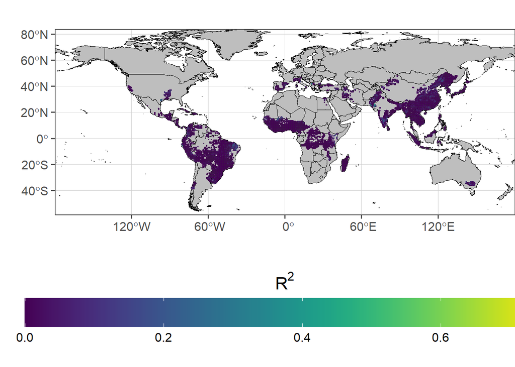

```r
ens_map <- crop_data[["ri1"]] %>%
  group_by(lat, lon) %>%
 filter(sd(difftrend_obs) > 0, sd(difftrend_sim) > 0) %>% # only gridcells where the standard deviation is bigger than 0
    summarise(rsquared = cor(difftrend_obs, difftrend_sim) ^2,
             ctr = ctr) %>%
distinct()

map_rsquared <- base_map +
  geom_tile(data = ens_map, aes(x = lon, y = lat, color = rsquared), size = 0.2) +
  scale_color_viridis(name = expression(R^2), option = "viridis", limits = c(0, 0.75),
                      guide = guide_colorbar(barwidth = unit(18, "cm"),  # Increase colorbar width
                                            barheight = unit(1, "cm"),  # Set colorbar height
                                            title.position = "top",  # Position title above the colorbar
                                             title.vjust = 1,  # Add space between title and colorbar
                                              title.hjust = 0.5  # Center the title
                      ))+
  labs(x = "", y = "") +
  theme(legend.position = "bottom", legend.title = element_text(size = 17))

map_rsquared
```

```r
# Save the figure
#ggsave(file.path(base_path, "GGCMI-validation/results/main/suppfig2_GlobalPerformanceMap_ri1.png"), map_rsquared, width = 18, height = 8, dpi = 300)
```

### Supplementary figure 3 – (WINTER) WHEAT performance

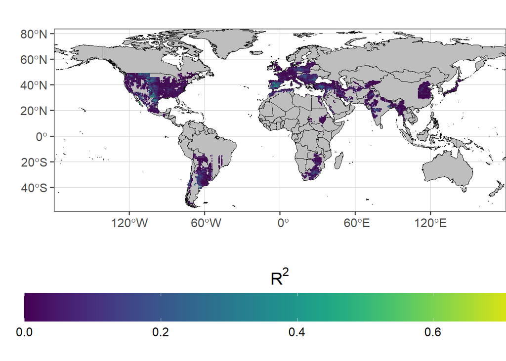

```r
ens_map <- crop_data[["wwh"]] %>%
  group_by(lat, lon) %>%
 filter(sd(difftrend_obs) > 0, sd(difftrend_sim) > 0) %>% # only gridcells where the standard deviation is bigger than 0
    summarise(rsquared = cor(difftrend_obs, difftrend_sim) ^2,
             ctr = ctr) %>%
distinct()

map_rsquared <- base_map +
  geom_tile(data = ens_map, aes(x = lon, y = lat, color = rsquared), size = 0.2) +
  scale_color_viridis(name = expression(R^2), option = "viridis", limits = c(0, 0.75),
                      guide = guide_colorbar(barwidth = unit(18, "cm"),  # Increase colorbar width
                                            barheight = unit(1, "cm"),  # Set colorbar height
                                            title.position = "top",  # Position title above the colorbar
                                             title.vjust = 1,  # Add space between title and colorbar
                                              title.hjust = 0.5  # Center the title
                      ))+
  labs(x = "", y = "") +
  theme(legend.position = "bottom", legend.title = element_text(size = 17))

map_rsquared
```

```r
# Save the figure
#ggsave(file.path(base_path, "GGCMI-validation/results/main/suppfig3_GlobalPerformanceMap_wwh.png"), map_rsquared, width = 18, height = 8, dpi = 300)
```

### Supplementary figure 4 – SOY performance

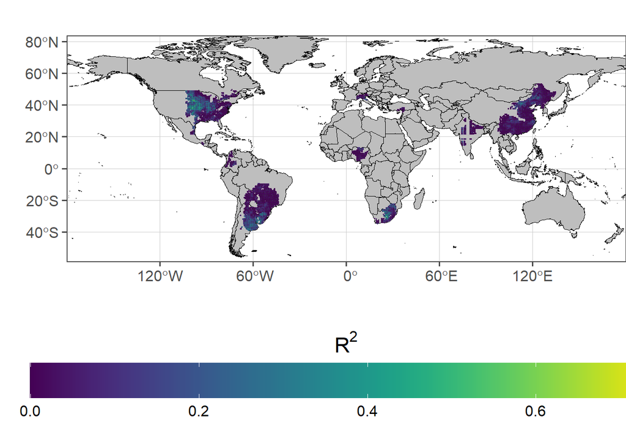

```r
ens_map <- crop_data[["soy"]] %>%
  group_by(lat, lon) %>%
 filter(sd(difftrend_obs) > 0, sd(difftrend_sim) > 0) %>% # only gridcells where the standard deviation is bigger than 0
    summarise(rsquared = cor(difftrend_obs, difftrend_sim) ^2,
             ctr = ctr) %>%
distinct()

map_rsquared <- base_map +
  geom_tile(data = ens_map, aes(x = lon, y = lat, color = rsquared), size = 0.2) +
  scale_color_viridis(name = expression(R^2), option = "viridis", limits = c(0, 0.75),
                      guide = guide_colorbar(barwidth = unit(18, "cm"),  # Increase colorbar width
                                            barheight = unit(1, "cm"),  # Set colorbar height
                                            title.position = "top",  # Position title above the colorbar
                                             title.vjust = 1,  # Add space between title and colorbar
                                              title.hjust = 0.5  # Center the title
                      ))+
  labs(x = "", y = "") +
  theme(legend.position = "bottom", legend.title = element_text(size = 17))

map_rsquared
```

```r
# Save the figure
#ggsave(file.path(base_path, "GGCMI-validation/results/main/suppfig4_GlobalPerformanceMap_soy.png"), map_rsquared, width = 18, height = 8, dpi = 300)
```

### Supplementary figure 5 – MAIZE performance

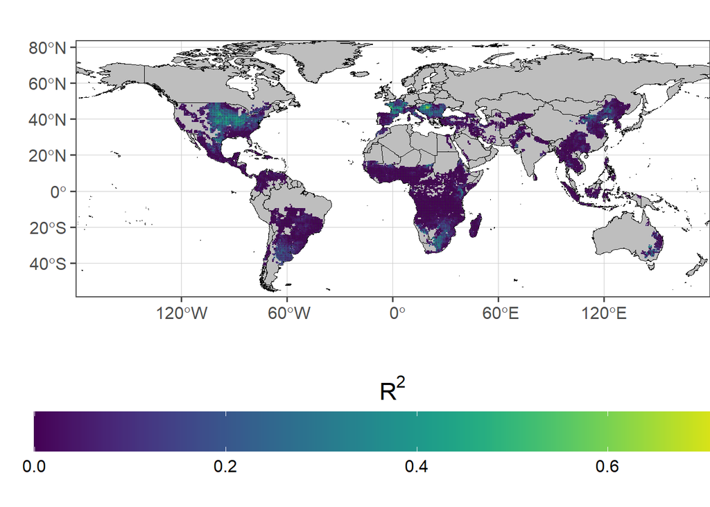

```r
ens_map <- crop_data[["mai"]] %>%
  group_by(lat, lon) %>%
 filter(sd(difftrend_obs) > 0, sd(difftrend_sim) > 0) %>% # only gridcells where the standard deviation is bigger than 0
    summarise(rsquared = cor(difftrend_obs, difftrend_sim) ^2,
             ctr = ctr) %>%
distinct()

map_rsquared <- base_map +
  geom_tile(data = ens_map, aes(x = lon, y = lat, color = rsquared), size = 0.2) +
  scale_color_viridis(name = expression(R^2), option = "viridis", limits = c(0, 0.75),
                      guide = guide_colorbar(barwidth = unit(18, "cm"),  # Increase colorbar width
                                            barheight = unit(1, "cm"),  # Set colorbar height
                                            title.position = "top",  # Position title above the colorbar
                                             title.vjust = 1,  # Add space between title and colorbar
                                              title.hjust = 0.5  # Center the title
                      ))+
  labs(x = "", y = "") +
  theme(legend.position = "bottom", legend.title = element_text(size = 17))

map_rsquared
```

```r
# Save the figure
#ggsave(file.path(base_path, "GGCMI-validation/results/main/suppfig5_GlobalPerformanceMap_mai.png"), map_rsquared, width = 18, height = 8, dpi = 300)
```

## Supplementary figures 6-10

In addition to the maps with general performance, we also plot the total production per grid cell observed in the benchmark data. We calculate the total production as the yield multiplied by the total crop area of the grid cell and then take the mean production value across the years.

### Supplementary figure 6 - aggregated crop production

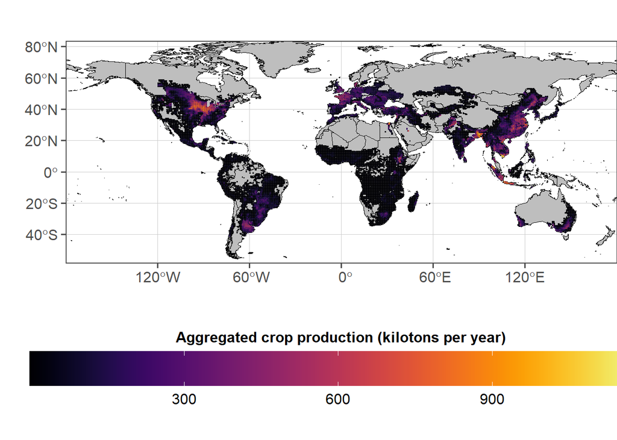

```r
production <- crop_data[["aggr"]] %>%
  mutate(production = yield * total_area * 1/10000 *1/1000) %>%
  group_by(lat, lon) %>%
  summarise(mean_production = mean(production, na.rm= TRUE))

map <- base_map +
  geom_tile(
    data = production,
    aes(x = lon, y = lat, color = mean_production),
    size = 0.2
  ) +
  scale_x_continuous(expand = c(0, 0)) +
  scale_y_continuous(expand = c(0, 0)) +
  scale_color_viridis(
    name = "Aggregated crop production (kilotons per year)",
    option = "inferno",
    guide = guide_colorbar(
      barwidth = unit(18, "cm"),
      barheight = unit(1, "cm"),
      title.position = "top",
      title.vjust = 1,
      title.hjust = 0.5
    )
  )  +
  labs(x = "", y = "") +
  theme(legend.position = "bottom")

map
```

```r
# Save the figure
#ggsave(file.path(base_path, "/aggr_production.png"), map_rsquared, width = 24, height = 12, dpi = 300)
```

### Supplementary figure 7 - RICE production

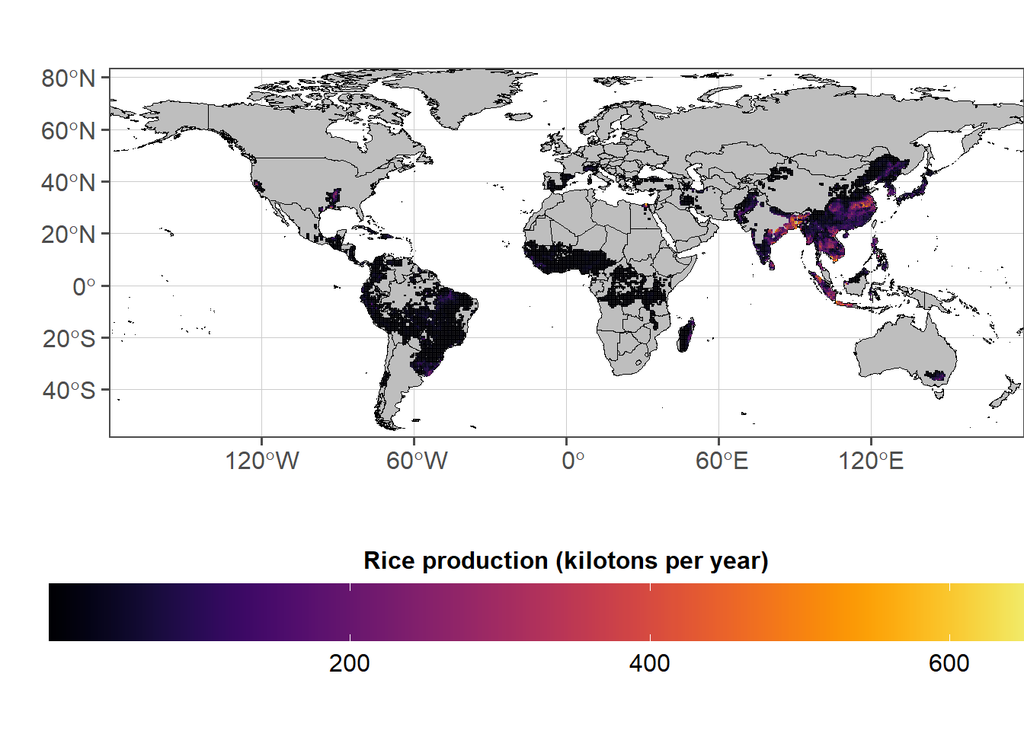

```r
production <- crop_data[["ri1"]] %>%
  mutate(production = yield * total_area * 1/10000 *1/1000) %>%
  group_by(lat, lon) %>%
  summarise(mean_production = mean(production, na.rm= TRUE))

map <- base_map +
  geom_tile(
    data = production,
    aes(x = lon, y = lat, color = mean_production),
    size = 0.2
  ) +
  scale_x_continuous(expand = c(0, 0)) +
  scale_y_continuous(expand = c(0, 0)) +
  scale_color_viridis(
    name = "Rice production (kilotons per year)",
    option = "inferno",
    guide = guide_colorbar(
      barwidth = unit(18, "cm"),
      barheight = unit(1, "cm"),
      title.position = "top",
      title.vjust = 1,
      title.hjust = 0.5
    )
  )  +
  labs(x = "", y = "") +
  theme(legend.position = "bottom")

map
```

```r
# Save the figure
#ggsave(file.path(base_path, "/ri1_production.png"), map_rsquared, width = 24, height = 12, dpi = 300)
```

### Supplementary figure 8 - WHEAT production

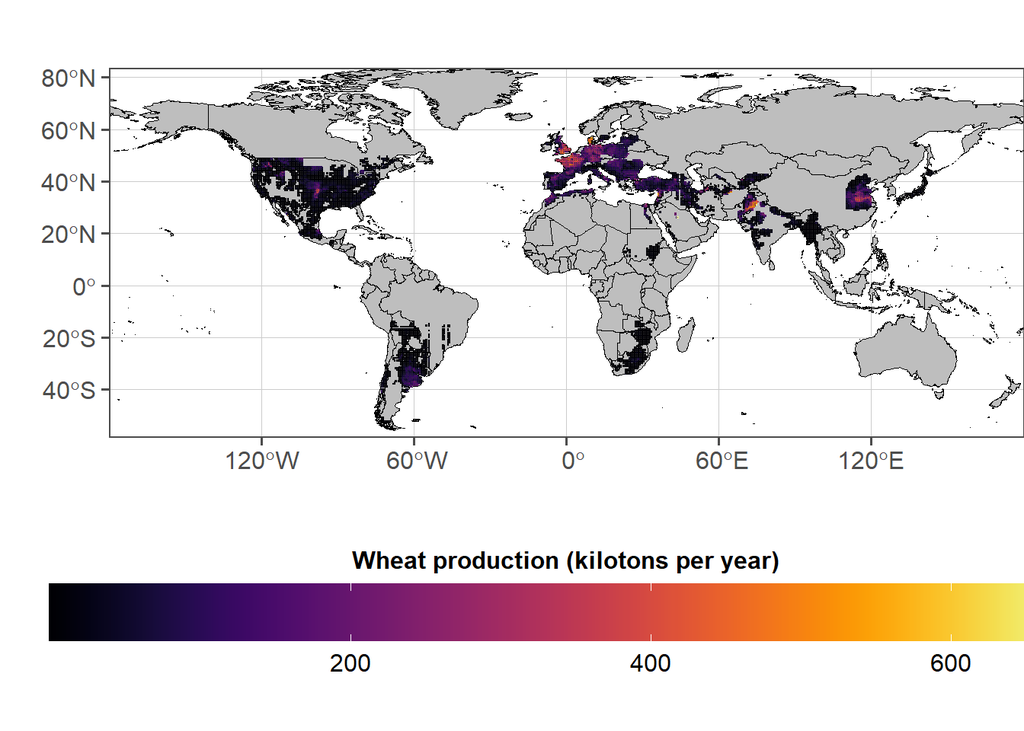

```r
production <- crop_data[["wwh"]] %>%
  mutate(production = yield * total_area  * 1/10000 *1/1000) %>%
  group_by(lat, lon) %>%
  summarise(mean_production = mean(production, na.rm= TRUE))

map <- base_map +
  geom_tile(
    data = production,
    aes(x = lon, y = lat, color = mean_production),
    size = 0.2
  ) +
  scale_x_continuous(expand = c(0, 0)) +
  scale_y_continuous(expand = c(0, 0)) +
  scale_color_viridis(
    name = "Wheat production (kilotons per year)",
    option = "inferno",
    guide = guide_colorbar(
      barwidth = unit(18, "cm"),
      barheight = unit(1, "cm"),
      title.position = "top",
      title.vjust = 1,
      title.hjust = 0.5
    )
  )  +
  labs(x = "", y = "") +
  theme(legend.position = "bottom")

map
```

```r
# Save the figure
#ggsave(file.path(base_path, "/wwh_production.png"), map_rsquared, width = 24, height = 12, dpi = 300)
```

### Supplementary figure 9 – SOY production

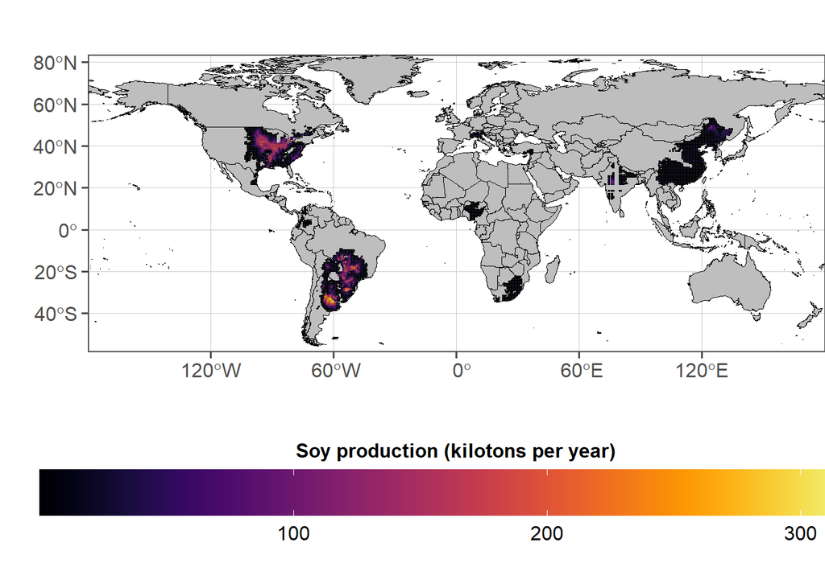

```r
production <- crop_data[["soy"]] %>%
  mutate(production = yield * total_area  * 1/10000 *1/1000) %>%
  group_by(lat, lon) %>%
  summarise(mean_production = mean(production, na.rm= TRUE))

map <- base_map +
  geom_tile(
    data = production,
    aes(x = lon, y = lat, color = mean_production),
    size = 0.2
  ) +
  scale_x_continuous(expand = c(0, 0)) +
  scale_y_continuous(expand = c(0, 0)) +
  scale_color_viridis(
    name = "Soy production (kilotons per year)",
    option = "inferno",
    guide = guide_colorbar(
      barwidth = unit(18, "cm"),
      barheight = unit(1, "cm"),
      title.position = "top",
      title.vjust = 1,
      title.hjust = 0.5
    )
  )  +
  labs(x = "", y = "") +
  theme(legend.position = "bottom")

map
```

```r
# Save the figure
#ggsave(file.path(base_path, "/soy_production.png"), map_rsquared, width = 24, height = 12, dpi = 300)
```

### Supplementary figure 10 – MAIZE production

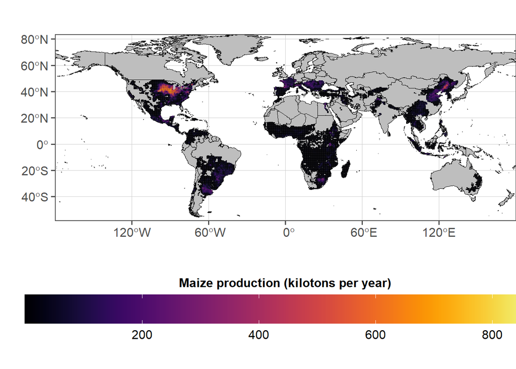

```r
production <- crop_data[["mai"]] %>%
  mutate(production = yield * total_area  * 1/10000 *1/1000) %>%
  group_by(lat, lon) %>%
  summarise(mean_production = mean(production, na.rm= TRUE))

map <- base_map +
  geom_tile(
    data = production,
    aes(x = lon, y = lat, color = mean_production),
    size = 0.2
  ) +
  scale_x_continuous(expand = c(0, 0)) +
  scale_y_continuous(expand = c(0, 0)) +
  scale_color_viridis(
    name = "Maize production (kilotons per year)",
    option = "inferno",
    guide = guide_colorbar(
      barwidth = unit(18, "cm"),
      barheight = unit(1, "cm"),
      title.position = "top",
      title.vjust = 1,
      title.hjust = 0.5
    )
  )  +
  labs(x = "", y = "") +
  theme(legend.position = "bottom")

map
```

```r
# Save the figure
#ggsave(file.path(base_path, "/mai_production.png"), map_rsquared, width = 24, height = 12, dpi = 300)
```